# Getting Started with BayesianDEB

## Overview

**BayesianDEB** provides a complete Bayesian framework for Dynamic Energy Budget (DEB) modelling. It wraps pre-written Stan models with a clean R interface for data preparation, model specification, fitting, diagnostics, and visualisation.

The package implements four model types:

| Type | Stan model | Description |
| --- | --- | --- |
| `individual` | 2-state (E, V) | Single individual growth |
| `growth_repro` | 3-state (E, V, R) | Growth + reproduction |
| `hierarchical` | 2-state + random effects | Multi-individual with partial pooling |
| `debtox` | 4-state (E, V, R, D) | Toxicokinetic-toxicodynamic |

## Installation

```r
# Install cmdstanr (required backend)
install.packages("cmdstanr",
  repos = c("https://stan-dev.r-universe.dev", getOption("repos")))
cmdstanr::install_cmdstan()

# Install BayesianDEB
# remotes::install_github("sciom/BayesianDEB")
```

The chunks below are executed only when `cmdstanr` and a working CmdStan installation are available — otherwise they are skipped. To keep build time within JSS limits we use 2 chains and 300 + 300 iterations, which is sufficient for illustration but **not** for publication-grade inference. Re-run with `chains = 4`, `iter_warmup = iter_sampling = 1000` for production fits.

## Example: Individual Growth Model

### 1. Prepare Data

```r
data(eisenia_growth)

# Use first individual
df1 <- eisenia_growth[eisenia_growth$id == 1, ]
dat <- bdeb_data(growth = df1, f_food = 1.0)
dat
```

```
#>
#> ── BDEB Data ──
#>
#> ℹ Individuals: 1
#> ℹ Endpoints: growth
#> ℹ Functional response (f): 1
#> → Growth: 13 observations, t = [0, 84]
```

### 2. Specify Model

```r
mod <- bdeb_model(
  data   = dat,
  type   = "individual",
  priors = list(
    p_Am    = prior_lognormal(mu = 1.5, sigma = 0.5),
    p_M     = prior_lognormal(mu = -1.0, sigma = 0.5),
    kappa   = prior_beta(a = 3, b = 2),
    sigma_L = prior_halfnormal(sigma = 0.05)
  )
)
mod
```

```
#>
#> ── BDEB Model Specification ──
#>
#> ℹ Type: individual
#> ℹ Stan model: bdeb_individual_growth
#> ℹ Individuals: 1
#> ℹ Endpoints: growth
#>
#> ── Priors
#> →   p_Am: LogNormal(1.5, 0.5)
#> →   p_M: LogNormal(-1.0, 0.5)
#> →   kappa: Beta(3.0, 2.0)
#> →   sigma_L: HalfNormal(0.05)
#> →   v: LogNormal(-1.5, 1.0)
#> →   E_G: LogNormal(6.0, 1.0)
#> →   E0: LogNormal(0.0, 1.0)
#> →   L0: LogNormal(-2.0, 1.0)
```

Unspecified priors are filled from `prior_default("individual")`.

### 3. Fit Model

```r
fit <- bdeb_fit(mod,
                chains = 2, iter_warmup = 300, iter_sampling = 300,
                seed = 123, refresh = 100)
```

```
#> ℹ Running MCMC (2 chains, 300 iterations each)
#> Running MCMC with 2 parallel chains...
#>
#> Chain 1 Iteration:   1 / 600 [  0%]  (Warmup)
#> Chain 2 Iteration:   1 / 600 [  0%]  (Warmup)
#> Chain 2 Informational Message: The current Metropolis proposal is about to be rejected because of the following issue:
#> Chain 2 Exception: normal_lpdf: Scale parameter is 0, but must be positive! (in '/tmp/Rtmp1KA7pd/model-c47577a84097.stan', line 111, column 4 to column 35)
#> Chain 2 If this warning occurs sporadically, such as for highly constrained variable types like covariance matrices, then the sampler is fine,
#> Chain 2 but if this warning occurs often then your model may be either severely ill-conditioned or misspecified.
#> Chain 2
#> Chain 1 Iteration: 100 / 600 [ 16%]  (Warmup)
#> Chain 2 Iteration: 100 / 600 [ 16%]  (Warmup)
#> Chain 1 Iteration: 200 / 600 [ 33%]  (Warmup)
#> Chain 2 Iteration: 200 / 600 [ 33%]  (Warmup)
#> Chain 2 Iteration: 300 / 600 [ 50%]  (Warmup)
#> Chain 2 Iteration: 301 / 600 [ 50%]  (Sampling)
#> Chain 1 Iteration: 300 / 600 [ 50%]  (Warmup)
#> Chain 1 Iteration: 301 / 600 [ 50%]  (Sampling)
#> Chain 2 Iteration: 400 / 600 [ 66%]  (Sampling)
#> Chain 1 Iteration: 400 / 600 [ 66%]  (Sampling)
#> Chain 2 Iteration: 500 / 600 [ 83%]  (Sampling)
#> Chain 1 Iteration: 500 / 600 [ 83%]  (Sampling)
#> Chain 2 Iteration: 600 / 600 [100%]  (Sampling)
#> Chain 2 finished in 4.5 seconds.
#> Chain 1 Iteration: 600 / 600 [100%]  (Sampling)
#> Chain 1 finished in 5.0 seconds.
#>
#> Both chains finished successfully.
#> Mean chain execution time: 4.7 seconds.
#> Total execution time: 5.1 seconds.
```

```r
fit
```

```
#>
#> ── BDEB Fit ──
#>
#> ℹ Model type: individual
#> ℹ Algorithm: sampling (NUTS)
#> ℹ Chains: 2, Warmup: 300, Sampling: 300
#> ✔ No divergent transitions
```

### 4. Diagnostics

```r
bdeb_diagnose(fit)
```

```
#>
#> ── BDEB Diagnostics (individual) ──
#>
#> ✔ No divergent transitions.
#> ✔ Treedepth OK.
#> ✔ E-BFMI OK (all > 0.3).
#>
#> ── Parameter Summary
#> ✔ All R-hat < 1.01.
#> ! Low bulk ESS (<400) for: E_G, L0, sigma_L, x_sol[1,2], x_sol[2,2], x_sol[3,2], x_sol[9,2], x_sol[10,2], x_sol[11,2], x_sol[12,2], x_sol[13,2], L_hat[1], L_hat[2], L_hat[3], L_hat[9], L_hat[10], L_hat[11], L_hat[12], L_hat[13]
#>  variable     mean       sd   median       5%      95% rhat ess_bulk ess_tail
#>      p_Am   5.2470 2.86e+00   4.5464   2.1325 1.10e+01    1      708      351
#>       p_M   0.4251 2.30e-01   0.3677   0.1679 8.67e-01    1      745      421
#>     kappa   0.5942 1.97e-01   0.6011   0.2413 9.14e-01    1      639      254
#>       E_G 465.0713 3.42e+02 387.3190 110.9284 1.08e+03    1      336      284
#>        E0   1.5403 1.58e+00   1.0254   0.2406 4.93e+00    1      692      441
#>        L0   0.1097 1.09e-02   0.1093   0.0930 1.28e-01    1      327      136
#>   sigma_L   0.0185 4.75e-03   0.0173   0.0125 2.77e-02    1      362      373
#> ℹ 39 latent-state rows hidden; use `print(x, full = TRUE)` or `summary(x)$table` to see all.
```

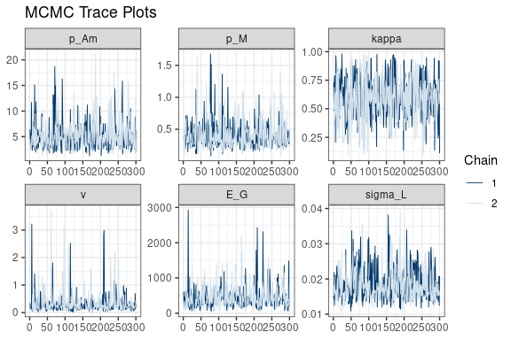

```r
plot(fit, type = "trace")
```

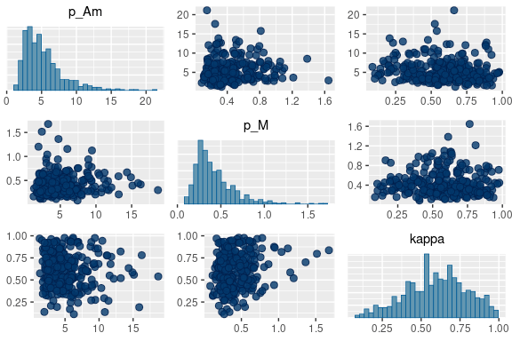

```r
# `bayesplot::mcmc_pairs` requires gridExtra (a Suggests of bayesplot).
plot(fit, type = "pairs", pars = c("p_Am", "p_M", "kappa"))
```

### 5. Posterior Predictive Checks

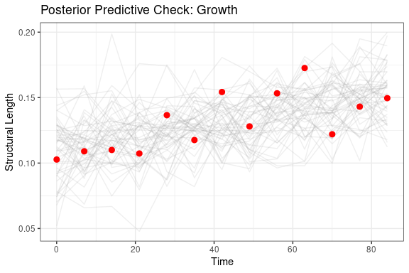

```r
ppc <- bdeb_ppc(fit, type = "growth")
plot(ppc)
```

### 6. Derived Quantities

```r
bdeb_derived(fit, quantities = c("L_inf", "growth_rate"))
```

```
#> # A draws_df: 600 iterations, 1 chains, and 2 variables
#>    L_inf growth_rate
#> 1   13.6     0.00018
#> 2    4.6     0.00065
#> 3   11.5     0.00043
#> 4    6.7     0.00021
#> 5   16.3     0.00068
#> 6    3.1     0.00011
#> 7    8.3     0.00092
#> 8    7.9     0.00030
#> 9   13.5     0.00038
#> 10   3.4     0.00022
#> # ... with 590 more draws
#> # ... hidden reserved variables {'.chain', '.iteration', '.draw'}
```

### 7. Trajectory Plot

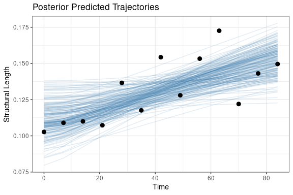

```r
plot(fit, type = "trajectory", n_draws = 200)
```

## Example: Hierarchical Model (Multiple Individuals)

For illustration we use a 5-individual subset; the full multi-individual analysis with all 21 individuals is in the replication archive.

```r
dat_all <- bdeb_data(
  growth = eisenia_growth[eisenia_growth$id %in% 1:5, ],
  f_food = 1.0
)

mod_hier <- bdeb_model(dat_all, type = "hierarchical")

fit_hier <- bdeb_fit(mod_hier,
                     chains = 2, iter_warmup = 300, iter_sampling = 300,
                     seed = 123, refresh = 100)
```

[output not shown]

```r
bdeb_diagnose(fit_hier)
```

[output not shown]

```r
summary(fit_hier, pars = c("mu_log_p_Am", "sigma_log_p_Am", "p_M", "kappa"))
```

```
#> # A tibble: 4 × 9
#>   variable        mean    sd median   `5%` `95%`  rhat ess_bulk ess_tail
#>   <chr>          <dbl> <dbl>  <dbl>  <dbl> <dbl> <dbl>    <dbl>    <dbl>
#> 1 mu_log_p_Am    1.56  0.904  1.53  0.0902 3.11   1.01     391.    395.
#> 2 sigma_log_p_Am 0.542 0.540  0.392 0.0339 1.52   1.02     142.    286.
#> 3 p_M            1.97  2.81   1.18  0.134  5.97   1.01     108.     35.9
#> 4 kappa          0.515 0.206  0.517 0.176  0.857  1.01     250.    188.
```

## Example: DEBtox Model

```r
data(debtox_growth)

# Concentration mapping
conc_map <- setNames(
  c(0, 20, 80, 200),
  c("1", "2", "3", "4")
)

dat_tox <- bdeb_data(
  growth = debtox_growth,
  concentration = conc_map,
  f_food = 1.0
)

mod_tox <- bdeb_tox(dat_tox, stress = "assimilation")
```

For this **demo only**, we use **variational inference (ADVI)** which gives an approximation of the posterior in seconds rather than minutes. The replication archive uses full HMC (NUTS) which is the publication-grade method.

```r
fit_tox <- bdeb_fit(mod_tox, algorithm = "variational",
                    seed = 123, refresh = 0)
```

[output not shown]

```r
bdeb_ec50(fit_tox)
```

```
#>
#> ── DEBtox Effect Concentrations
#>  parameter  mean median   sd  lower upper
#>       EC50 28.01   6.40 93.3 0.4941 127.3
#>        NEC  8.59   1.15 28.9 0.0338  39.1
```

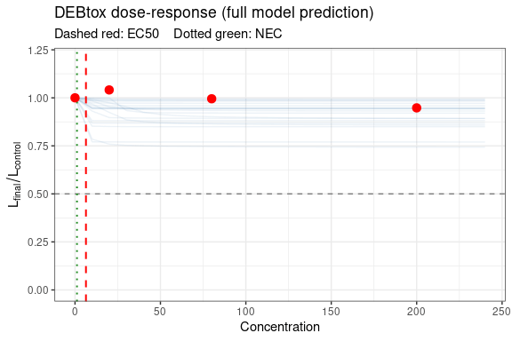

```r
plot_dose_response(fit_tox, n_draws = 20, n_conc = 25, dt = 1.0)
```

## Prior Specification

BayesianDEB follows the prior recommendations of Kooijman (2010) and the AmP collection (Marques et al., 2018):

- **Positive rate parameters** (p_Am, p_M, v, E_G): Log-normal priors
- **Allocation fraction** (kappa): Beta prior
- **Scale parameters** (sigma_L): Half-normal priors
- **Hierarchical SDs**: Exponential priors

```r
# View defaults
prior_default("individual")
```

```
#> $p_Am
#> → lognormal(mu = 1, sigma = 1)
#>
#> $p_M
#> → lognormal(mu = -1, sigma = 1)
#>
#> $kappa
#> → beta(a = 2, b = 2)
#>
#> $v
#> → lognormal(mu = -1.5, sigma = 1)
#>
#> $E_G
#> → lognormal(mu = 6, sigma = 1)
#>
#> $E0
#> → lognormal(mu = 0, sigma = 1)
#>
#> $L0
#> → lognormal(mu = -2, sigma = 1)
#>
#> $sigma_L
#> → halfnormal(sigma = 0.1)
```

```r
# Override specific priors
my_priors <- list(
  p_Am  = prior_lognormal(mu = 2.0, sigma = 0.3),
  kappa = prior_beta(a = 5, b = 2)
)
```

## Observation Models

The default likelihood is Gaussian for growth and negative binomial for reproduction. Switch via `observation`:

```r
# Robust to outliers
mod <- bdeb_model(dat, type = "individual",
  observation = list(growth = obs_student_t(nu = 5)))

# Multiplicative error
mod <- bdeb_model(dat, type = "individual",
  observation = list(growth = obs_lognormal()))
```

## Further Reading

- Kooijman, S.A.L.M. (2010). *Dynamic Energy Budget Theory for Metabolic Organisation*. 3rd edition. Cambridge University Press.
- Jager, T., Heugens, E.H.W. and Kooijman, S.A.L.M. (2006). Making sense of ecotoxicological test results: towards application of process-based models. *Ecotoxicology*, 15(3), 305–314.
- Carpenter, B. et al. (2017). Stan: A probabilistic programming language. *Journal of Statistical Software*, 76(1).
- Gelman, A. et al. (2013). *Bayesian Data Analysis*. 3rd edition. Chapman & Hall/CRC.